# nb04_Subject-Level-Analysis

**COGNESTIC-2026**

- **Author:** [Dace Apšvalka](https://www.mrc-cbu.cam.ac.uk/people/dace.apsvalka/)
- **Date:** August 2026
- **conda environment**: mri conda environment.

# fMRI Data Analysis: Subject-Level Analysis

Once the data have been pre-processed, we can proceed to the analysis. In this tutorial, we will focus on subject-level (or first-level) fMRI data analysis using [Nilearn](https://nilearn.github.io/stable/index.html). This process involves:

- constructing a design matrix,
- fitting the model to the data, and
- computing beta maps (i.e., the estimated response for each condition) or contrast maps.

Subject-level analysis is a crucial step before progressing to group-level analysis.

For analysing fMRI data, we commonly use general linear model (GLM). A GLM in fMRI analysis has the **BOLD signal** as the **outcome** variable (derived from the pre-processed functional MRI images) and **predictor** variables such as **events** (e.g., task conditions) and **confounds** (e.g., motion parameters). Typically analysis is performed by constructing a separate model for each voxel - **a mass univariate approach**.

For more information on GLM, please see Rik's Stats tutorial.

And here are some recommended short videos to help better understand the principles of fMRI analysis:

```python
from IPython.display import display, HTML

display(HTML('''
<div style="width: 1200px; margin: 0; display: flex; justify-content: space-around;">
    <div style="text-align: center;">
        <h3><a href="https://www.youtube.com/embed/OyLKMb9FNhg">GLM applied to fMRI (11 min)</a></h3>
        <iframe width="560" height="315" src="https://www.youtube.com/embed/OyLKMb9FNhg" frameborder="0" allow="picture-in-picture" allowfullscreen></iframe>
    </div>
    <div style="text-align: center;">
        <h3><a href="https://www.youtube.com/embed/7MibM1ATai4">Conditions and contrasts (12 min)</a></h3>
        <iframe width="560" height="315" src="https://www.youtube.com/embed/7MibM1ATai4" frameborder="0" allow="picture-in-picture" allowfullscreen></iframe>
    </div>
</div>

<div style="width: 1200px; margin: 0; display: flex; justify-content: space-around;">
    <div style="text-align: center;">
        <h3><a href="https://www.youtube.com/embed/DEtwsFdFwYc">Nuisance variables (14 min)</a></h3>
        <iframe width="560" height="315" src="https://www.youtube.com/embed/DEtwsFdFwYc" frameborder="0" allow="picture-in-picture" allowfullscreen></iframe>
    </div>
    <div style="text-align: center;">
        <h3><a href="https://www.youtube.com/embed/AalIM9-5-Pk">Multiple Comparisons (9 min)</a></h3>
        <iframe width="560" height="315" src="https://www.youtube.com/embed/AalIM9-5-Pk" frameborder="0" allow="picture-in-picture" allowfullscreen></iframe>
    </div>
</div>
'''))
```

[GLM applied to fMRI (11 min)](https://www.youtube.com/embed/OyLKMb9FNhg)

[video not shown]

[Conditions and contrasts (12 min)](https://www.youtube.com/embed/7MibM1ATai4)

[video not shown]

[Nuisance variables (14 min)](https://www.youtube.com/embed/DEtwsFdFwYc)

[video not shown]

[Multiple Comparisons (9 min)](https://www.youtube.com/embed/AalIM9-5-Pk)

[video not shown]

**Table of contents**

1. Import required packages
2. Retrieve the preprocessed (fMRIprep) data
3. Setting up GLM model components  
   3.1. Dependent variable (Y): BOLD signal from each voxel of the functional MRI images  
   3.2. Predictors (X): Events  
   3.3. Predictors: Confounds
4. Performing the GLM analysis  
   4.1. Creating the First Level Model  
   4.2. Fitting the model  
   4.3. Inspecting the Design Matrix
5. Contrast specification  
   5.1. A simple case contrast  
   5.2. Contrast scaling  
   5.3. The final contrasts for our model
6. Computing contrasts and plotting result maps  
   6.1. Control the False Positive Rate  
   6.2. False Discovery Rate (FDR) correction  
   6.3. Family Wise Error (FWE) correction  
   6.4. Cluster threshold
7. First Level for multiple subjects  
   7.1. A generic first-level analysis script  
   7.2. Processing multiple subjects in parallel
8. Parametric Modulation

## Import required packages

```python
import pandas as pd # for data manipulation
import numpy as np # for numerical operations

import matplotlib.pyplot as plt # for basic plotting

from bids import BIDSLayout # to fetch data from BIDS-compliant datasets

# Nilearn modules, for the analysis of brain volumes, plotting, etc., https://nilearn.github.io/
from nilearn.interfaces.fmriprep import load_confounds
from nilearn.glm.first_level import FirstLevelModel, compute_regressor, glover_hrf, spm_hrf
from nilearn.glm.thresholding import threshold_stats_img
from nilearn.plotting import plot_design_matrix, plot_contrast_matrix, plot_stat_map, plot_roi
from nilearn.maskers import NiftiSpheresMasker

import nibabel as nib # to load and save neuroimaging data
```

## Retrieve the preprocessed (fMRIprep) data

BIDS Apps, such as `fMRIprep`, output data into a data structure similar to `BIDS` organisation principals. And these data also can be inspected using [PyBIDS](https://bids-standard.github.io/pybids/index.html).

```python
# --- Set up the paths to the BIDS data directory which includes derivatives
fmri_data_dir = 'FaceRecognition/data' # BIDS format data directory

# --- Set up the BIDS layoutt and include the derivatives in it
layout = BIDSLayout(fmri_data_dir, derivatives = True)

# or to include only a specific derivatives folder
# layout = BIDSLayout(fmri_data_dir, derivatives = 'path/to/derivatives')
```

## Setting up GLM model components

Remember (or refer to Rik's stats) that GLM typically is expressed as **Y = XB + e**, where **Y** is a vector containing the data, **X** is the 'design matrix' that defines the model for the data, **B** (or 'Betas') is a vector of parameters to be estimated, and **e** represents random error.

In the next sections, we will set up our GLM model by specifying the following:

- **The data (Y)**, which are our pre-processed functional images. These contain the time series data (length n; 208 in our case) for each voxel.
- **The design matrix (X)**, where we specify the effects (predictors) that may have influenced the acquired signal in the data. At a minimum, these effects include our experimental conditions, which we specify through event files containing the names and onsets of the conditions. Additionally, we can include other predictors, such as confounding (nuisance) variables, which are known to have occurred and likely influenced the data. Including these can help explain the acquired signal. We get a large list of confounding variables from the fMRIPrep output (confound files). The size of the design matrix must be n x p (time series length x number of predictors). There should be more data points (n) than predictors (p), so be cautious not to include too many confounding variables.

Nilearn will use the specified inputs for the GLM analysis and compute the beta estimates for each predictor. We can then define contrasts to compare beta estimates between conditions—for example, to test whether seeing Faces had a greater effect on the signal than seeing Scrambled images.

Let's set up our GLM model.

### Dependent variable (Y): BOLD signal from each voxel of the functional MRI images

We need to specify which MRI images we want to analyse. Here, we will focus on a single subject's **9 functional runs**. Using PyBIDS, we can easily locate the preprocessed files required for the analysis. Let's retrieve the preprocessed functional image files for **subject sub-15** (since this is the subject used for demo of [SPM-Matlab analysis of this dataset](https://doi.org/10.3389/fnins.2019.00300)).

```python
sID = '15'

preproc_functional_files = layout.get(
    subject = sID,
    datatype = 'func',
    desc = 'preproc',
    space = 'MNI152NLin6Asym',
    extension = '.nii.gz',
    return_type = 'filename'
)

print('\nSubject''s', sID, 'preprocessed functional images:')
print(*preproc_functional_files, sep='\n')
```

```
Subjects 15 preprocessed functional images:
/imaging/correia/da05/workshops/2026-COGNESTIC/06_fMRI/FaceRecognition/data/derivatives/fmriprep/sub-15/ses-mri/func/sub-15_ses-mri_task-facerecognition_run-01_space-MNI152NLin6Asym_res-9_desc-preproc_bold.nii.gz
/imaging/correia/da05/workshops/2026-COGNESTIC/06_fMRI/FaceRecognition/data/derivatives/fmriprep/sub-15/ses-mri/func/sub-15_ses-mri_task-facerecognition_run-02_space-MNI152NLin6Asym_res-9_desc-preproc_bold.nii.gz
/imaging/correia/da05/workshops/2026-COGNESTIC/06_fMRI/FaceRecognition/data/derivatives/fmriprep/sub-15/ses-mri/func/sub-15_ses-mri_task-facerecognition_run-03_space-MNI152NLin6Asym_res-9_desc-preproc_bold.nii.gz
/imaging/correia/da05/workshops/2026-COGNESTIC/06_fMRI/FaceRecognition/data/derivatives/fmriprep/sub-15/ses-mri/func/sub-15_ses-mri_task-facerecognition_run-04_space-MNI152NLin6Asym_res-9_desc-preproc_bold.nii.gz
/imaging/correia/da05/workshops/2026-COGNESTIC/06_fMRI/FaceRecognition/data/derivatives/fmriprep/sub-15/ses-mri/func/sub-15_ses-mri_task-facerecognition_run-05_space-MNI152NLin6Asym_res-9_desc-preproc_bold.nii.gz
/imaging/correia/da05/workshops/2026-COGNESTIC/06_fMRI/FaceRecognition/data/derivatives/fmriprep/sub-15/ses-mri/func/sub-15_ses-mri_task-facerecognition_run-06_space-MNI152NLin6Asym_res-9_desc-preproc_bold.nii.gz
/imaging/correia/da05/workshops/2026-COGNESTIC/06_fMRI/FaceRecognition/data/derivatives/fmriprep/sub-15/ses-mri/func/sub-15_ses-mri_task-facerecognition_run-07_space-MNI152NLin6Asym_res-9_desc-preproc_bold.nii.gz
/imaging/correia/da05/workshops/2026-COGNESTIC/06_fMRI/FaceRecognition/data/derivatives/fmriprep/sub-15/ses-mri/func/sub-15_ses-mri_task-facerecognition_run-08_space-MNI152NLin6Asym_res-9_desc-preproc_bold.nii.gz
/imaging/correia/da05/workshops/2026-COGNESTIC/06_fMRI/FaceRecognition/data/derivatives/fmriprep/sub-15/ses-mri/func/sub-15_ses-mri_task-facerecognition_run-09_space-MNI152NLin6Asym_res-9_desc-preproc_bold.nii.gz
```

We will also specify the subject's anatomical image (warped to the standard space) to use it as a background image when plotting results.

```python
preprocessed_anatomical_file = layout.get(
    subject = sID,
    datatype = 'anat',
    space = 'MNI152NLin6Asym',
    desc = 'preproc',
    extension = '.nii.gz',
    return_type ='filename'
)[0]

print('Subject''s', sID, 'preprocessed anatomical image:')
print(preprocessed_anatomical_file)
```

```
Subjects 15 preprocessed anatomical image:
/imaging/correia/da05/workshops/2026-COGNESTIC/06_fMRI/FaceRecognition/data/derivatives/fmriprep/sub-15/ses-mri/anat/sub-15_ses-mri_space-MNI152NLin6Asym_res-9_desc-preproc_T1w.nii.gz
```

The functional images contain **time series data for each voxel** in the brain. When we later run a GLM, we will fit a model to each voxel’s time series and compute beta estimates.

To get an intuition for what this data looks like, let’s first extract the time series from a single voxel in the first run.

We’ll use Nilearn’s `NiftiSpheresMasker` to do this:

- We provide the coordinates of the voxel of interest.
- We specify the TR (repetition time), which is how often the scanner collected a brain volume.
- We standardize the signal (z-score), so that it has mean = 0 and standard deviation = 1.

The result will be the activity over time in that voxel, showing how its signal changed during the scan.

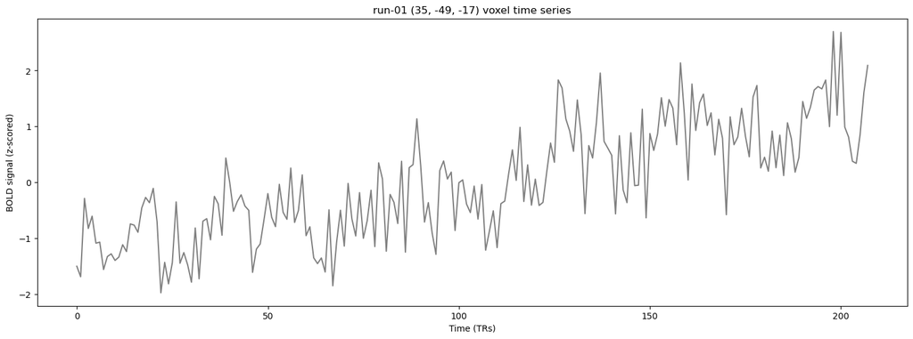

```python
# voxel of interest
MNI_coord = [(35, -49, -17)]

# get the TR
TR = layout.get_tr()

# extract the time series
coord_masker = NiftiSpheresMasker(
  MNI_coord,
  t_r=TR,
  standardize='zscore'
)
coord_time_series = coord_masker.fit_transform(preproc_functional_files[0])

# plot the time series
plt.figure(figsize=(18, 6))

plt.plot(coord_time_series, color='grey')

plt.title(f"run-01 {MNI_coord[0]} voxel time series")
plt.xlabel('Time (TRs)')
plt.ylabel('BOLD signal (z-scored)')
plt.show()
```

The BOLD signal in this voxel during the 7-minute functional run comes from various sources. We want to determine whether our experimental conditions (viewing Famous, Unfamiliar, or Scrambled faces) contribute to this signal, and if so, by how much. To better estimate this, we aim to regress out other potential contributors that we are not interested in, such as head movement artefacts, scanner drift, and other noise.

### Predictors (X): Events

We need to specify the events that occurred during the functional acquisitions. The event files are stored in the `data/func` folder, and again, we can use `PyBIDS` to locate them.

```python
event_files = layout.get(
    subject = sID,
    datatype = 'func',
    suffix = 'events',
    extension = ".tsv",
    return_type = 'filename'
)
print('Subject''s', sID, 'event files:')
print(*event_files, sep='\n')
```

```
Subjects 15 event files:
/imaging/correia/da05/workshops/2026-COGNESTIC/06_fMRI/FaceRecognition/data/sub-15/ses-mri/func/sub-15_ses-mri_task-facerecognition_run-01_events.tsv
/imaging/correia/da05/workshops/2026-COGNESTIC/06_fMRI/FaceRecognition/data/sub-15/ses-mri/func/sub-15_ses-mri_task-facerecognition_run-02_events.tsv
/imaging/correia/da05/workshops/2026-COGNESTIC/06_fMRI/FaceRecognition/data/sub-15/ses-mri/func/sub-15_ses-mri_task-facerecognition_run-03_events.tsv
/imaging/correia/da05/workshops/2026-COGNESTIC/06_fMRI/FaceRecognition/data/sub-15/ses-mri/func/sub-15_ses-mri_task-facerecognition_run-04_events.tsv
/imaging/correia/da05/workshops/2026-COGNESTIC/06_fMRI/FaceRecognition/data/sub-15/ses-mri/func/sub-15_ses-mri_task-facerecognition_run-05_events.tsv
/imaging/correia/da05/workshops/2026-COGNESTIC/06_fMRI/FaceRecognition/data/sub-15/ses-mri/func/sub-15_ses-mri_task-facerecognition_run-06_events.tsv
/imaging/correia/da05/workshops/2026-COGNESTIC/06_fMRI/FaceRecognition/data/sub-15/ses-mri/func/sub-15_ses-mri_task-facerecognition_run-07_events.tsv
/imaging/correia/da05/workshops/2026-COGNESTIC/06_fMRI/FaceRecognition/data/sub-15/ses-mri/func/sub-15_ses-mri_task-facerecognition_run-08_events.tsv
/imaging/correia/da05/workshops/2026-COGNESTIC/06_fMRI/FaceRecognition/data/sub-15/ses-mri/func/sub-15_ses-mri_task-facerecognition_run-09_events.tsv
```

Event files contain the names of our experimental conditions, their onset times (in seconds), and their durations (in seconds). The events table will have as many rows as there are trials you want to include in the model.

```python
# load and display one of the event files
events_run1 = pd.read_csv(event_files[0], sep='\t')
events_run1
```

|  | onset | duration | circle_duration | trial_type | trigger | button_pushed | response_time | stim_file |
| --- | --- | --- | --- | --- | --- | --- | --- | --- |
| 0 | 0.000 | 0.910 | 0.416 | IniFF | 5 | 7 | 1.903 | func/f005.bmp |
| 1 | 3.124 | 0.996 | 0.450 | IniFF | 5 | 4 | 1.041 | func/f012.bmp |
| 2 | 6.564 | 0.830 | 0.577 | ImmFF | 6 | 4 | 1.300 | func/f012.bmp |
| 3 | 9.620 | 0.908 | 0.432 | IniSF | 17 | 7 | 1.040 | func/s007.bmp |
| 4 | 12.894 | 0.885 | 0.557 | IniUF | 13 | 4 | 1.357 | func/u003.bmp |
| ... | ... | ... | ... | ... | ... | ... | ... | ... |
| 88 | 380.126 | 0.914 | 0.563 | DelUF | 15 | 7 | 0.662 | func/u005.bmp |
| 89 | 383.250 | 0.896 | 0.441 | IniUF | 13 | 7 | 0.890 | func/u015.bmp |
| 90 | 386.423 | 0.818 | 0.510 | DelUF | 15 | 7 | 0.648 | func/u007.bmp |
| 91 | 389.480 | 1.000 | 0.478 | IniUF | 13 | 4 | 0.826 | func/u013.bmp |
| 92 | 392.804 | 0.955 | 0.567 | ImmUF | 14 | 4 | 0.753 | func/u013.bmp |

93 rows × 8 columns

There are 9 trial_types, which come from a 3x3 factorial design which crosses **stimulus type** (**Famous Face**, `FF`; **Unfamiliar Face**, `UF`; **Scrambled Face**, `SF`) with **presentation** (**Initial**, `Ini`; **Immediate Repeat**, `Imm`; **Delayed Repeat**, `Del`).

In the GLM's design matrix, we include one regressor (the same length as the time series data points) for each condition. The regressor represents the predicted BOLD response to the stimulus. The BOLD signal does not simply switch from 0 to 1 (on or off); instead, it follows a specific shape known as the **haemodynamic response function (HRF)**. The HRF models the delayed and dispersed nature of the BOLD signal in response to neural activity, typically peaking a few seconds after the stimulus and then gradually returning to baseline.

To obtain our condition's predicted BOLD response, **we convolve the onset and duration times of the condition with an HRF**. Several HRF models have been derived from research, with two of the most commonly used in typical populations being Glover's HRF and SPM's HRF.

To see how it works, let's create a regressor for the **IniFF** condition. We'll use the condition's onset and duration times from the event file and convolve them with Glover's HRF. Nilearn has a built-in function for this ([glm.first_level.compute_regressor](https://nilearn.github.io/stable/modules/generated/nilearn.glm.first_level.compute_regressor.html)), so we will use that.

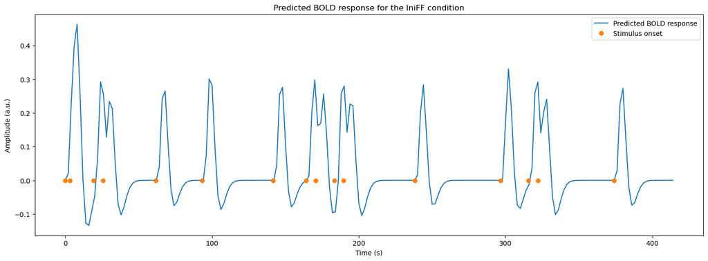

```python
# Filter events_run1 DataFrame for the 'IniFF' condition
IniFF_events = events_run1[events_run1['trial_type'] == 'IniFF']

# Extract onsets and durations for the 'IniFF' condition
onsets_IniFF = IniFF_events['onset'].values
durations_IniFF = IniFF_events['duration'].values
# Set amplitudes to 1 for all events
amplitudes_IniFF = np.ones_like(onsets_IniFF)

# Create a list of frame times (number of data points x TR, sampled every TR)
bold_image = nib.load(preproc_functional_files[0])
num_TRs = bold_image.shape[3]

frame_times = np.arange(0, num_TRs*TR, TR)

# Create the regressor for 'IniFF' condition
regressor_IniFF, _ = compute_regressor(
  [onsets_IniFF, durations_IniFF, amplitudes_IniFF],
  hrf_model='glover',
  frame_times=frame_times
)

# plot the regressor and also show the onsets
plt.figure(figsize=(18, 6))

plt.plot(frame_times, regressor_IniFF)
plt.plot(onsets_IniFF, np.zeros_like(onsets_IniFF), 'o')

plt.xlabel('Time (s)')
plt.ylabel('Amplitude (a.u.)')
plt.legend(['Predicted BOLD response', 'Stimulus onset'])
plt.title('Predicted BOLD response for the IniFF condition')
```

💡 **Note:** We created the regressor by hand above just to show what’s happening under the hood. In practice, you don’t need to manually build these regressors in Nilearn. When setting up the first-level model, you simply provide the event files, making sure they contain the *onset*, *duration*, and *trial_type* columns, and Nilearn will generate the regressors for you.

### Predictors: Confounds

Confounds represent fluctuations with a potential non-neuronal origin, such as head motion artefacts, scanner noise, and cardiac or respiratory effects. We can include them in the GLM as regressors of no interest to minimize the confounding effects of non-neuronal signals. fMRIPrep calculates a wide range of possible confounds. You can find detailed information in the [fMRIPrep documentation](https://fmriprep.org/en/stable/outputs.html#confounds).

Which confounding variables you include in the GLM depends on the analysis you want to perform. The most well-established confounds are the six head-motion parameters (three rotations and three translations). If your dataset includes physiological recordings (e.g., heart rate, respiration), you might consider including these as confounds. If not, you might include PCA components from CompCor, a method implemented in fMRIPrep that identifies noise components from CSF and white matter signals. **However, please read the [fMRIPrep documentation on confounds](https://fmriprep.org/en/stable/outputs.html#confounds) carefully before including any additional confounds, and never include all confounds in the GLM design matrix!**

If your study has specific considerations (e.g., participant behaviour or task-related noise), you may need to include additional custom confounds.

The confounds computed by `fMRIPrep` can be found in the `data/derivatives/fmriprep/{sub}/func/` directory. They are stored separately for each run in `.tsv` files, with one column for each confound variable. Let's use `PyBIDS` to locate these files.

```python
confound_files = layout.get(
    subject = sID,
    datatype = 'func',
    desc = 'confounds',
    extension = ".tsv",
    return_type = 'filename'
)

print('Subject''s', sID, 'confound files:')
print(*confound_files, sep='\n')
```

```
Subjects 15 confound files:
/imaging/correia/da05/workshops/2026-COGNESTIC/06_fMRI/FaceRecognition/data/derivatives/fmriprep/sub-15/ses-mri/func/sub-15_ses-mri_task-facerecognition_run-01_desc-confounds_timeseries.tsv
/imaging/correia/da05/workshops/2026-COGNESTIC/06_fMRI/FaceRecognition/data/derivatives/fmriprep/sub-15/ses-mri/func/sub-15_ses-mri_task-facerecognition_run-02_desc-confounds_timeseries.tsv
/imaging/correia/da05/workshops/2026-COGNESTIC/06_fMRI/FaceRecognition/data/derivatives/fmriprep/sub-15/ses-mri/func/sub-15_ses-mri_task-facerecognition_run-03_desc-confounds_timeseries.tsv
/imaging/correia/da05/workshops/2026-COGNESTIC/06_fMRI/FaceRecognition/data/derivatives/fmriprep/sub-15/ses-mri/func/sub-15_ses-mri_task-facerecognition_run-04_desc-confounds_timeseries.tsv
/imaging/correia/da05/workshops/2026-COGNESTIC/06_fMRI/FaceRecognition/data/derivatives/fmriprep/sub-15/ses-mri/func/sub-15_ses-mri_task-facerecognition_run-05_desc-confounds_timeseries.tsv
/imaging/correia/da05/workshops/2026-COGNESTIC/06_fMRI/FaceRecognition/data/derivatives/fmriprep/sub-15/ses-mri/func/sub-15_ses-mri_task-facerecognition_run-06_desc-confounds_timeseries.tsv
/imaging/correia/da05/workshops/2026-COGNESTIC/06_fMRI/FaceRecognition/data/derivatives/fmriprep/sub-15/ses-mri/func/sub-15_ses-mri_task-facerecognition_run-07_desc-confounds_timeseries.tsv
/imaging/correia/da05/workshops/2026-COGNESTIC/06_fMRI/FaceRecognition/data/derivatives/fmriprep/sub-15/ses-mri/func/sub-15_ses-mri_task-facerecognition_run-08_desc-confounds_timeseries.tsv
/imaging/correia/da05/workshops/2026-COGNESTIC/06_fMRI/FaceRecognition/data/derivatives/fmriprep/sub-15/ses-mri/func/sub-15_ses-mri_task-facerecognition_run-09_desc-confounds_timeseries.tsv
```

Let's get a list of all confounds of the first functional run.

```python
confounds_run1 = pd.read_table(confound_files[0])

print('Number of confounds in run 1:', len(list(confounds_run1)))
print('Number of data points for ech confound:', len(confounds_run1), '\n')
#print(*list(confounds_run1), sep='\n')
confounds_run1
```

```
Number of confounds in run 1: 212
Number of data points for ech confound: 208
```

|  | global_signal | global_signal_derivative1 | global_signal_power2 | global_signal_derivative1_power2 | csf | csf_derivative1 | csf_power2 | csf_derivative1_power2 | white_matter | white_matter_derivative1 | ... | rot_x_derivative1_power2 | rot_x_power2 | rot_y | rot_y_derivative1 | rot_y_power2 | rot_y_derivative1_power2 | rot_z | rot_z_derivative1 | rot_z_derivative1_power2 | rot_z_power2 |
| --- | --- | --- | --- | --- | --- | --- | --- | --- | --- | --- | --- | --- | --- | --- | --- | --- | --- | --- | --- | --- | --- |
| 0 | 795.294277 | NaN | 632492.987683 | NaN | 1205.429348 | NaN | 1.453060e+06 | NaN | 713.524504 | NaN | ... | NaN | 2.634625e-07 | 0.000030 | NaN | 9.135264e-10 | NaN | 0.000274 | NaN | NaN | 7.511930e-08 |
| 1 | 795.132733 | -0.161544 | 632236.063633 | 0.026096 | 1199.808957 | -5.620391 | 1.439542e+06 | 31.588796 | 714.462834 | 0.938330 | ... | 4.066613e-11 | 2.569567e-07 | -0.000389 | -0.000419 | 1.513506e-07 | 1.757811e-07 | 0.000292 | 0.000018 | 3.256942e-10 | 8.533760e-08 |
| 2 | 793.456792 | -1.675941 | 629573.680544 | 2.808780 | 1197.333036 | -2.475921 | 1.433606e+06 | 6.130184 | 714.561069 | 0.098235 | ... | 1.132500e-08 | 1.603922e-07 | -0.000172 | 0.000217 | 2.971038e-08 | 4.694632e-08 | 0.000217 | -0.000075 | 5.641512e-09 | 4.709594e-08 |
| 3 | 796.667041 | 3.210249 | 634678.373906 | 10.305698 | 1196.994656 | -0.338380 | 1.432796e+06 | 0.114501 | 715.046148 | 0.485079 | ... | 7.571798e-08 | 4.565151e-07 | -0.000158 | 0.000014 | 2.496147e-08 | 2.066406e-10 | 0.000326 | 0.000109 | 1.185769e-08 | 1.062167e-07 |
| 4 | 795.187114 | -1.479927 | 632322.545623 | 2.190185 | 1196.450486 | -0.544169 | 1.431494e+06 | 0.296120 | 715.348226 | 0.302078 | ... | 4.465149e-08 | 2.156209e-07 | -0.000370 | -0.000212 | 1.369518e-07 | 4.497708e-08 | 0.000315 | -0.000011 | 1.118095e-10 | 9.943616e-08 |
| ... | ... | ... | ... | ... | ... | ... | ... | ... | ... | ... | ... | ... | ... | ... | ... | ... | ... | ... | ... | ... | ... |
| 203 | 797.227925 | -0.858045 | 635572.363939 | 0.736241 | 1204.901344 | -1.628502 | 1.451787e+06 | 2.652019 | 719.121296 | -0.434643 | ... | 1.575614e-09 | 4.996723e-07 | 0.000074 | 0.000039 | 5.412913e-09 | 1.504315e-09 | -0.003469 | 0.000310 | 9.633574e-08 | 1.203639e-05 |
| 204 | 796.091964 | -1.135961 | 633762.415055 | 1.290407 | 1204.338580 | -0.562764 | 1.450431e+06 | 0.316704 | 718.574736 | -0.546560 | ... | 8.611376e-07 | 2.672735e-06 | 0.000394 | 0.000320 | 1.552525e-07 | 1.026872e-07 | -0.003653 | -0.000183 | 3.354759e-08 | 1.334083e-05 |
| 205 | 795.548132 | -0.543831 | 632896.831110 | 0.295753 | 1204.550860 | 0.212280 | 1.450943e+06 | 0.045063 | 719.208489 | 0.633752 | ... | 2.215773e-07 | 1.355199e-06 | 0.000009 | -0.000385 | 8.146236e-11 | 1.482214e-07 | -0.003623 | 0.000030 | 8.832784e-10 | 1.312461e-05 |
| 206 | 795.597366 | 0.049234 | 632975.169127 | 0.002424 | 1204.534790 | -0.016069 | 1.450904e+06 | 0.000258 | 718.657825 | -0.550663 | ... | 3.665176e-07 | 3.121714e-07 | -0.000248 | -0.000257 | 6.156850e-08 | 6.612903e-08 | -0.003331 | 0.000292 | 8.500140e-08 | 1.109716e-05 |
| 207 | 797.156714 | 1.559348 | 635458.827115 | 2.431566 | 1205.984504 | 1.449714 | 1.454399e+06 | 2.101670 | 719.410877 | 0.753052 | ... | 7.873243e-08 | 7.044513e-07 | -0.000578 | -0.000330 | 3.338424e-07 | 1.086764e-07 | -0.003484 | -0.000152 | 2.319529e-08 | 1.213505e-05 |

208 rows × 212 columns

As we can see, the fMRIPrep confounds file contains many possible nuisance regressors, and only a selected subset should be added to the GLM design matrix. In this example, we will include only the most commonly used confounds—the **six motion parameters**.

**There are two main ways to select them:**

*1. Select columns directly from the fMRIPrep confounds TSV file.*

> This gives full and transparent control over the regressors included in the model.

```python
# Which confounds are of interest for the GLM?
confounds_of_interest = ['rot_x', 'rot_y', 'rot_z', 'trans_x', 'trans_y', 'trans_z']

# From each run's confound file, extract the confounds of interest and replace NaN with 0
confounds_for_glm = []
for conf_file in confound_files:
    this_conf = pd.read_table(conf_file)
    conf_subset = this_conf[confounds_of_interest]
    confounds_for_glm.append(conf_subset)

# Inspect the selected regressors
confounds_for_glm[0].head()
```

|  | rot_x | rot_y | rot_z | trans_x | trans_y | trans_z |
| --- | --- | --- | --- | --- | --- | --- |
| 0 | -0.000513 | 0.000030 | 0.000274 | -0.047662 | -0.048473 | 0.018206 |
| 1 | -0.000507 | -0.000389 | 0.000292 | -0.048418 | -0.058472 | 0.022559 |
| 2 | -0.000400 | -0.000172 | 0.000217 | -0.061884 | -0.027687 | -0.006128 |
| 3 | -0.000676 | -0.000158 | 0.000326 | -0.048395 | -0.018090 | 0.023410 |
| 4 | -0.000464 | -0.000370 | 0.000315 | -0.048402 | -0.048456 | 0.011915 |

*2. Use `nilearn.interfaces.fmriprep.load_confounds`.*

> This function locates the confounds associated with an fMRIPrep-preprocessed image and selects regressors according to a specified denoising strategy. It supports groups of regressors such as motion estimates, white-matter and CSF signals, CompCor components, global signal, and motion scrubbing.

> The function takes the preprocessed BOLD filenames and automatically finds the corresponding fMRIPrep confounds TSV and JSON files. It returns the selected confounds together with a **sample mask** for each run. A sample mask contains the indices of the volumes that should be retained for analysis. A value of `None` indicates that all volumes in that run should be retained. Volumes may be excluded because they were identified as non-steady-state volumes or, when motion scrubbing is requested, as motion outliers. Non-steady-state volumes are checked automatically, even when "non_steady_state" is not explicitly included in strategy.

> When fitting the first-level model, the sample masks should be supplied to `FirstLevelModel.fit()` using the `sample_masks` argument so that the same volumes are removed from both the BOLD data and the design matrix.

> For a multi-run analysis, `FirstLevelModel.fit()` expects every element of a supplied sample_masks list to be an array of retained-volume indices. Therefore, if some runs have a sample mask and others return None, the None entries should be replaced by arrays retaining all volumes. If all entries are None, pass `sample_masks=None`.

> See the [documentation](https://nilearn.github.io/dev/modules/generated/nilearn.interfaces.fmriprep.load_confounds.html) for more detailed information about the `load_confounds` function.

```python
# Select the six basic motion parameters from each run
confounds_for_glm, sample_masks = load_confounds(
    preproc_functional_files, # list of fMRIPrep-preprocessed BOLD files
    strategy=("motion",), # can be multiple strategies
    motion="basic"
)

# Prepare sample masks for FirstLevelModel.fit()
if all(mask is None for mask in sample_masks):
    sample_masks_for_glm = None
else:
    sample_masks_for_glm = [
        np.arange(len(confounds), dtype=int)
        if mask is None
        else mask
        for confounds, mask in zip(confounds_for_glm, sample_masks)
    ]

# Inspect the selected regressors
confounds_for_glm[0].head()
```

|  | rot_x | rot_y | rot_z | trans_x | trans_y | trans_z |
| --- | --- | --- | --- | --- | --- | --- |
| 0 | -0.001347 | 0.000057 | 0.002080 | -0.032058 | -0.001711 | 0.182592 |
| 1 | -0.001341 | -0.000362 | 0.002098 | -0.032815 | -0.011711 | 0.186946 |
| 2 | -0.001234 | -0.000145 | 0.002023 | -0.046281 | 0.019074 | 0.158259 |
| 3 | -0.001509 | -0.000131 | 0.002132 | -0.032792 | 0.028671 | 0.187797 |
| 4 | -0.001298 | -0.000343 | 0.002121 | -0.032799 | -0.001695 | 0.176301 |

*(The second approach returns a different result becauce by default, `load_confounds` mean-centres each confound within the run (`demean=True`). This removes arbitrary constant offsets and expresses nuisance regressors as deviations from their run average. In a first-level GLM containing a constant term, using centred or uncentred motion parameters should not affect task contrasts.)*

Both approaches are valid. Direct selection is useful for understanding exactly which columns enter the design matrix, whereas load_confounds provides a convenient and reproducible way to define more complex confound strategies.

Out of interest, we can use the `fit_transform` function again, which we previously used to extract an example voxel's time series, but this time, we'll include the confounds to regress them out from the data.

```python
## This we used to extact the original time series:
# coord_masker = NiftiSpheresMasker(
#     MNI_coord, t_r=TR, standardize='zscore'
# )
# coord_time_series = coord_masker.fit_transform(preproc_functional_files[0])

# Now we will extract the time series with the confounds of interest regressed out
coord_time_series_no_confounds = coord_masker.fit_transform(
  preproc_functional_files[0],
  confounds = confounds_for_glm[0]
  )
```

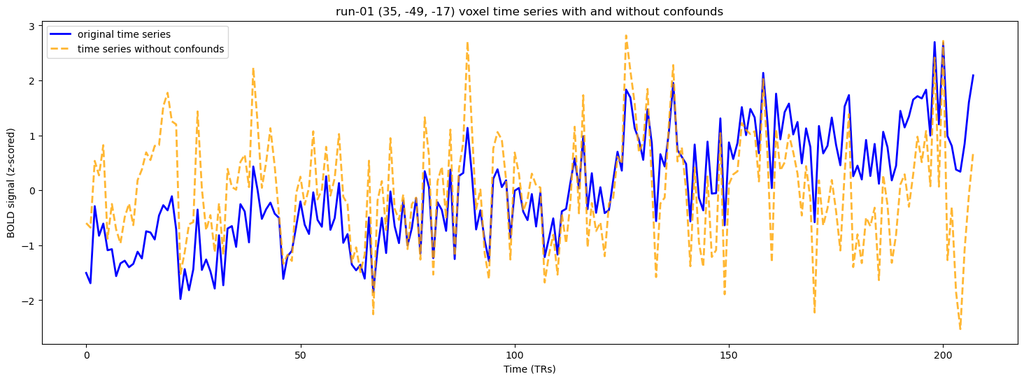

```python
# plot the time series with and without confounds
plt.figure(figsize=(18, 6))

plt.plot(coord_time_series, label='original time series', color='blue', linewidth=2)
plt.plot(coord_time_series_no_confounds, label='time series without confounds', color='orange', linestyle='--', linewidth=2, alpha=0.8)

plt.title(f"run-01 {MNI_coord[0]} voxel time series with and without confounds")
plt.xlabel('Time (TRs)')
plt.ylabel('BOLD signal (z-scored)')
plt.legend()
plt.show()
```

## Performing the GLM analysis

We now have everything we need for this subject: the BOLD images, event files, and confound regressors for each of the 9 functional runs. Nilearn can use these together to **fit a first-level GLM** and compute fixed-effects statistics (i.e., effects averaged across runs within this subject).

To do this, we will create a `FirstLevelModel` object. Based on the inputs we provide (BOLD images, event files, TR, confounds, etc.), it will automatically build the design matrix and estimate the model for us.

### Creating the First Level Model

Now we can specify the model with the parameters of our choice (see the [documentation](https://nilearn.github.io/stable/modules/generated/nilearn.glm.first_level.FirstLevelModel.html) for a full list of parameters). Here we will specify the folowing:

- **t_r** - repetition time (the sampling interval of the functional runs) in seconds. We can get it from our BIDS layout.
- **slice_time_ref**: *This parameter indicates the time of the reference slice used in the slice timing preprocessing step of the experimental runs. It is expressed as a percentage of the t_r (time repetition), so it can have values between 0. and 1. Default=0.*

  Alternativel, and perhaps preferably, we can obtain this information from the BIDS derivatives metadata. It also tells if the slice-time correction was performed at all.

  `data/derivatives/fmriprep/sub-15/ses-mri/func/sub-15_ses-mri_task-facerecognition_run-01_space-MNI152NLin6Asym_res-2_desc-preproc_bold.json`

  ```
    {
      "RepetitionTime": 2,
      "SkullStripped": false,
      "SliceTimingCorrected": true,
      "StartTime": 0.974,
      "TaskName": "facerecognition"
    }
  ```

The metadata indicates that slice-time correction was applied, and the start time was adjusted from 0 to 0.974—representing the middle of the acquisition range.

```python
# If slice timing correction was applied, get the slice time reference
slice_timing = layout.get_metadata(preproc_functional_files[0])
if slice_timing['SliceTimingCorrected']:
  slice_time_ref = slice_timing['StartTime'] / TR
  print('Slice timing reference:', slice_time_ref)
else:
  slice_time_ref = 0
  print('Slice timing correction was not applied')
```

```
Slice timing reference: 0.487
```

- **hrf_model**: defines the HRF model to be used. Possible options:
  - `spm`: This is the HRF model used in SPM.
  - `spm + derivative`: SPM model plus its time derivative. This gives 2 regressors.
  - `spm + derivative + dispersion`: Idem, plus dispersion derivative. This gives 3 regressors.
  - `glover`: This corresponds to the Glover HRF.
  - `glover + derivative`: The Glover HRF + time derivative. This gives 2 regressors.
  - `glover + derivative + dispersion`: Idem, plus dispersion derivative. This gives 3 regressors.
  - `fir`: Finite impulse response basis. This is a set of delayed dirac models.

It can also be a custom model. In this case, a function should be provided for each regressor.

The choice of the HRF model is up to the user. There's little difference between using the SPM or Glover model. **In general, it is advisable to include temporal and dispersion derivatives to allow for variability across individuals and brain regions. However, you should only include these derivatives in designs that are efficient for estimating the HRF shape, i.e, have long times (~6+ secs) between trials, or jittered times between trials (e.g., 2-20 secs, often by virtue of randomly intermixing "null events"); for short stimulus-onset-asynchronies (SOAs) of ~2 secs between trials (with no null events), one cannot distinguish a delayed response to one trial (fit by the temporal derivative of the HRF) from a reduced amplitude on the subsequent trial.**

Let's see how, for example, SPM and Glover HRFs compare.

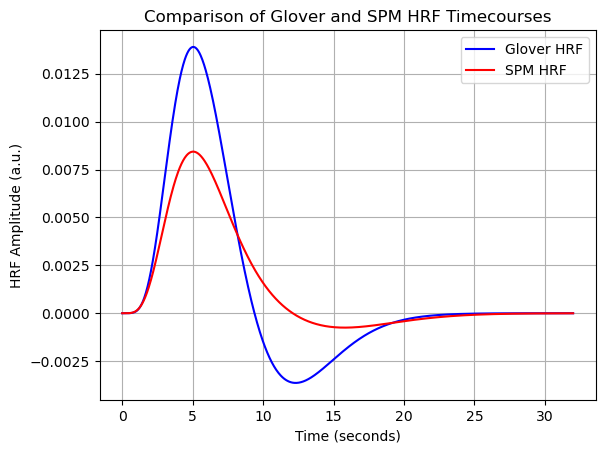

```python
# modeled time in seconds
time_length = 32

# Generate the HRF timecourses
glover_timecourse = glover_hrf(TR, time_length=time_length)
spm_timecourse = spm_hrf(TR, time_length=time_length)

# Plot the timecourses
timepoints = np.linspace(0, time_length, num=len(glover_timecourse))
plt.plot(timepoints, glover_timecourse, label='Glover HRF', color='blue')
plt.plot(timepoints, spm_timecourse, label='SPM HRF', color='red')
plt.title('Comparison of Glover and SPM HRF Timecourses')
plt.xlabel('Time (seconds)')
plt.ylabel('HRF Amplitude (a.u.)')
plt.legend()
plt.grid(True)
plt.show()
```

```python
# --- Get the brain mask
brain_mask = layout.get(
    subject=sID,
    datatype='anat',
    suffix='mask',
    desc='brain',
    space="MNI152NLin6Asym",
    extension='.nii.gz',
    return_type='filename'
    )
print("Brain mask file", brain_mask[0])
```

```
Brain mask file /imaging/correia/da05/workshops/2026-COGNESTIC/06_fMRI/FaceRecognition/data/derivatives/fmriprep/sub-15/ses-mri/anat/sub-15_ses-mri_space-MNI152NLin6Asym_res-9_desc-brain_mask.nii.gz
```

Our first-level model:

```python
first_level_model = FirstLevelModel(
    t_r = TR,
    slice_time_ref = slice_time_ref,
    smoothing_fwhm = 6, # a rule of thumb is 3x the voxel size
    hrf_model = 'SPM',  # (to better relate to analysis of these data using SPM12)
    drift_model = 'cosine', # default
    high_pass = 0.01, # default; Used only if drift_model is ‘cosine’ to set its cutoff frequency
    noise_model = 'ar1', # default
    mask_img = brain_mask[0],
    n_jobs = 2 # use two CPUs for computation
)
```

### Fitting the model

Now that we have specified the model, we can run it on our data. We need to include the list of our functional image files, the list of event timing files, and the list of our confound tables (one per run).

```python
# Fit the first-level model
first_level_model = first_level_model.fit(
  preproc_functional_files,
  events=event_files,
  confounds=confounds_for_glm,
  sample_masks=sample_masks_for_glm
  )
```

### Inspecting the Design Matrix

We can now inspect the design matrix of our GLM model (rows represent time, and columns contain the predictors).

The `design_matrices` is a list of 9 tables (one per run). Let's look at the first run's design matrix.

```
Design matrix for run 1
```

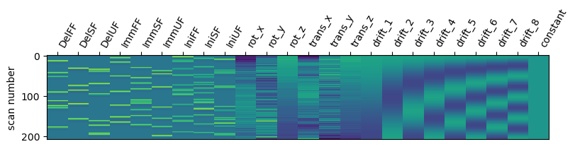

```python
# get the design matrices from the glm model
design_matrices = first_level_model.design_matrices_

print('Design matrix for run', 1)
plot_design_matrix(design_matrices[0], output_file=None)

fig = plt.gcf()
fig.set_size_inches(8,2)
plt.show()
```

Let’s also take a look at the data included in the design matrix.

```python
# display the design matrix of the first run
design_matrices[0]
```

|  | DelFF | DelSF | DelUF | ImmFF | ImmSF | ImmUF | IniFF | IniSF | IniUF | rot_x | ... | trans_z | drift_1 | drift_2 | drift_3 | drift_4 | drift_5 | drift_6 | drift_7 | drift_8 | constant |
| --- | --- | --- | --- | --- | --- | --- | --- | --- | --- | --- | --- | --- | --- | --- | --- | --- | --- | --- | --- | --- | --- |
| 0.974 | 0.0 | 0.0 | 0.000000 | 0.000000 | 0.0 | 0.000000 | 0.000520 | 0.000000 | 0.000000 | -0.001347 | ... | 0.182592 | 0.098055 | 0.098047 | 0.098033 | 0.098013 | 0.097988 | 0.097957 | 0.097921 | 0.097879 | 1.0 |
| 2.974 | 0.0 | 0.0 | 0.000000 | 0.000000 | 0.0 | 0.000000 | 0.073150 | 0.000000 | 0.000000 | -0.001341 | ... | 0.186946 | 0.098033 | 0.097957 | 0.097832 | 0.097656 | 0.097430 | 0.097153 | 0.096828 | 0.096452 | 1.0 |
| 4.974 | 0.0 | 0.0 | 0.000000 | 0.000000 | 0.0 | 0.000000 | 0.199902 | 0.000000 | 0.000000 | -0.001234 | ... | 0.158259 | 0.097988 | 0.097779 | 0.097430 | 0.096942 | 0.096316 | 0.095552 | 0.094653 | 0.093618 | 1.0 |
| 6.974 | 0.0 | 0.0 | 0.000000 | 0.000004 | 0.0 | 0.000000 | 0.305605 | 0.000000 | 0.000000 | -0.001509 | ... | 0.187797 | 0.097921 | 0.097511 | 0.096828 | 0.095874 | 0.094653 | 0.093167 | 0.091421 | 0.089419 | 1.0 |
| 8.974 | 0.0 | 0.0 | 0.000000 | 0.035488 | 0.0 | 0.000000 | 0.288458 | 0.000000 | 0.000000 | -0.001298 | ... | 0.176301 | 0.097832 | 0.097153 | 0.096027 | 0.094456 | 0.092450 | 0.090017 | 0.087168 | 0.083916 | 1.0 |
| ... | ... | ... | ... | ... | ... | ... | ... | ... | ... | ... | ... | ... | ... | ... | ... | ... | ... | ... | ... | ... | ... |
| 406.974 | 0.0 | 0.0 | -0.009032 | 0.000000 | 0.0 | -0.013115 | 0.000000 | -0.000221 | -0.021126 | -0.000127 | ... | -0.187217 | -0.097832 | 0.097153 | -0.096027 | 0.094456 | -0.092450 | 0.090017 | -0.087168 | 0.083916 | 1.0 |
| 408.974 | 0.0 | 0.0 | -0.004923 | 0.000000 | 0.0 | -0.017962 | 0.000000 | -0.000074 | -0.014616 | 0.000801 | ... | -0.214646 | -0.097921 | 0.097511 | -0.096828 | 0.095874 | -0.094653 | 0.093167 | -0.091421 | 0.089419 | 1.0 |
| 410.974 | 0.0 | 0.0 | -0.002394 | 0.000000 | 0.0 | -0.015566 | 0.000000 | 0.000000 | -0.008652 | 0.000330 | ... | -0.217630 | -0.097988 | 0.097779 | -0.097430 | 0.096942 | -0.096316 | 0.095552 | -0.094653 | 0.093618 | 1.0 |
| 412.974 | 0.0 | 0.0 | -0.001004 | 0.000000 | 0.0 | -0.010685 | 0.000000 | 0.000000 | -0.004506 | -0.000275 | ... | -0.200414 | -0.098033 | 0.097957 | -0.097832 | 0.097656 | -0.097430 | 0.097153 | -0.096828 | 0.096452 | 1.0 |
| 414.974 | 0.0 | 0.0 | -0.000409 | 0.000000 | 0.0 | -0.006211 | 0.000000 | 0.000000 | -0.002106 | 0.000006 | ... | -0.251839 | -0.098055 | 0.098047 | -0.098033 | 0.098013 | -0.097988 | 0.097957 | -0.097921 | 0.097879 | 1.0 |

208 rows × 24 columns

You may notice that the values for IniFF are somewhat different from the values in the event regressor `regressor_IniFF` that we calculated earlier (evaluate `regressor_IniFF[0:5]`). This is because the onset time of the events is not 0, but 0.974. This is the shift of half a TR to match the slice-timing.

```python
df_combined = pd.DataFrame({
  'IniFF before slice-timing': regressor_IniFF[0:5].flatten(),
  'IniFF after slice-timing': design_matrices[0]['IniFF'].head(5).values
})

print(df_combined)
```

```
   IniFF before slice-timing  IniFF after slice-timing
0                   0.000000                  0.000520
1                   0.021076                  0.073150
2                   0.228695                  0.199902
3                   0.397791                  0.305605
4                   0.463249                  0.288458
```

In the design matrix, we can observe several drift regressors. These are generated from the `drift_model` ('*cosine*') that we specified for our GLM model, capturing frequencies lower than the threshold set by the `high_pass` parameter. These regressors account for slow oscillations, which are unlikely to arise from our experimental conditions.

Now, let's plot the event regressors alongside the low-frequency drift regressors to better visualise these concepts.

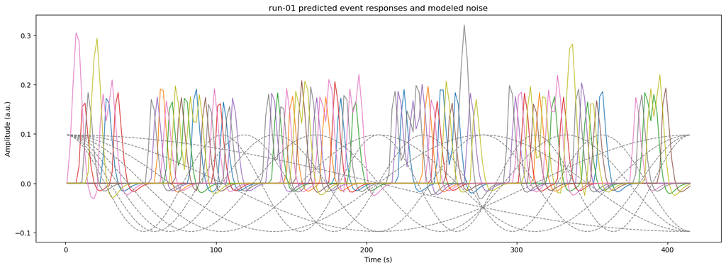

```python
dm = design_matrices[0]
event_regressors = dm.columns[:9]
drift_regressors = [col for col in dm.columns if col.startswith('drift_')]

plt.figure(figsize=(18, 6))

# Plot the predicted event responses
for event in event_regressors:
    plt.plot(dm.index, dm[event], lw=1)

# Plot the modeled noise
for drift in drift_regressors:
    plt.plot(dm.index, dm[drift], color='grey', lw=1, linestyle='--')

plt.title('run-01 predicted event responses and modeled noise')
plt.xlabel('Time (s)')
plt.ylabel('Amplitude (a.u.)')

plt.show()
```

We can see how the low-frequency drifts differ in shape and timing from the event-related signals. This helps illustrate how the GLM separates task-related neural activity from unrelated noise.

Ideally, the event regressors should not overlap much with the drift regressors. It's not a problem in our event-relighted design, but could be more problematic in slow block-designs. Significant overlap could suggest that some task-related variance is being captured by the noise model, reducing the sensitivity to detect neural signals.

Now, let's use the `fit_transform` function on our original example voxel's time series data. We will fit the nuisance regressors (motion and drift parameters) to the time series to remove the variance associated with these noise sources from the data.

We will plot this denoised time series against our predicted event responses. This will help visualise how well the model fits the data after accounting for nuisance factors. It provides an indication of how accurately the GLM captures the relationship between the experimental conditions and brain activity. A strong correspondence between the predicted responses and the denoised time series would suggest that the beta estimates are capturing meaningful signals related to the experimental conditions.

```python
nuiseance_regressors = design_matrices[0].columns[9:-1]
print('Nuisance regressors:', nuiseance_regressors)

# extract the time series with the nuiseance regressors regressed out
coord_time_series_denoised = coord_masker.fit_transform(
  preproc_functional_files[0],
  confounds = design_matrices[0][nuiseance_regressors]
  )
```

```
Nuisance regressors: Index(['rot_x', 'rot_y', 'rot_z', 'trans_x', 'trans_y', 'trans_z', 'drift_1',
       'drift_2', 'drift_3', 'drift_4', 'drift_5', 'drift_6', 'drift_7',
       'drift_8'],
      dtype='str')
```

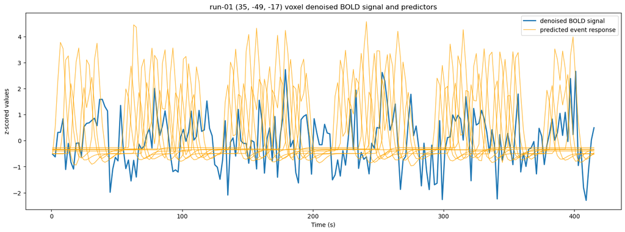

```python
# plot the regressors along the bold time series
plt.figure(figsize=(18, 6))

plt.plot(dm.index, coord_time_series_denoised, label='denoised BOLD signal', linewidth=2)

# Plot the predicted event responses
for event in event_regressors:
    zscored_event = (dm[event] - dm[event].mean()) / dm[event].std()
    plt.plot(dm.index, zscored_event,
             color='orange', lw=1, alpha=0.8)

plt.plot([],[], label="predicted event response", color='orange', lw=1, alpha=0.8)

plt.title(f"run-01 {MNI_coord[0]} voxel denoised BOLD signal and predictors")
plt.xlabel('Time (s)')
plt.ylabel('z-scored values')
plt.legend()
```

To obtain the actual beta estimates, we need to specify contrasts.

## Contrast specification

A contrast is a linear combination of the beta estimates that allows us to test specific hypotheses about the experimental conditions. Each condition or regressor in the model is assigned a weight in the contrast, and these weights are combined to produce a contrast estimate.

For example, to **compare two conditions** and test whether the mean activation in Condition A is greater than in Condition B, the contrast vector would be `c = [1, -1, 0, ...]`. Here, the 1 corresponds to Condition A, and the -1 corresponds to Condition B, indicating that we are comparing the two conditions. Zeros correspond to other conditions or regressors that are not part of the contrast. The resulting contrast estimate tests the difference between the beta estimates for these two conditions.

You can also test **combinations of conditions** by assigning equal weights to multiple conditions. For example, to test whether the mean activation across Conditions A and B is greater than that in Condition C, the contrast vector would be `[0.5, 0.5, -1, 0, ...]`. This represents the average of Conditions A and B compared to Condition C.

Contrast weights determine both what is being compared and the units of the resulting contrast estimate. For example, `[1, 1, -2]` and `[0.5, 0.5, -1]` test the same difference between Conditions A and B versus Condition C. They therefore produce the same t-, z-, and p-values. However, the estimate from `[1, 1, -2]` is twice as large. We normally use `[0.5, 0.5, -1]` because it has a clearer interpretation: the **average response to A and B minus the response to C**.

When multiple runs are fitted, Nilearn computes the contrast separately for each run and combines the results using fixed effects. This combination already averages across runs, so contrast weights should not be divided by the number of runs.

If you are interested in testing **the effect of a single condition** against the baseline, the contrast would be `[1, 0, 0, ...]`, where the 1 refers to the condition of interest, and the zeros correspond to other conditions or regressors that are not part of the contrast.

An **effects of interest** contrast is often used to assess the overall impact of all conditions or predictors of interest in the model. For effects of interest, a matrix-type contrast is used. This allows testing whether all conditions of interest, taken together, explain a significant amount of variance in the data. For example, if you have three conditions (A, B, C) and want to test whether they collectively explain significant variance, your matrix-type contrast would be:

$c = \begin{bmatrix} 1 & 0 & 0 \\ 0 & 1 & 0 \\ 0 & 0 & 1 \end{bmatrix}$

This type of contrast is commonly used in omnibus tests to determine whether any of the conditions have an effect, similar to an ANOVA in traditional statistics.

For a simple design, contrasts can be specified manually. In practice, however, the design matrix often contains additional columns, such as motion parameters, drift terms and a constant, and the number or order of columns may differ between analyses or runs. Manually constructing contrasts of the correct dimensions can therefore be error-prone.

We will use two helper functions:

- one for constructing **t-contrast vectors**, which test a specific directional comparison between conditions;
- one for constructing **F-contrast matrices**, which test several effects jointly without specifying a particular direction.

Both functions identify regressors using their design-matrix column names. A separate contrast is created for each run so that it matches the corresponding design matrix. Contrasts are not divided by the number of runs, because Nilearn combines the run-specific contrast estimates automatically.

### Creating t-contrasts

A t-contrast is represented by a single vector containing one weight for each column of the design matrix. The helper function below identifies columns using positive and negative name patterns. Columns matching the positive patterns receive equal weights that sum to +1, while columns matching the negative patterns receive equal weights that sum to −1. All other regressors receive a weight of zero.

When both positive and negative conditions are specified, the contrast represents the **mean of the positively weighted conditions minus the mean of the negatively weighted conditions**.

When only positive conditions are specified, the contrast tests their **average response against the implicit baseline**.

```python
# Helper function for constructing a contrast vector from
# the column names of a design matrix

def create_contrast_vector(
    design_matrix,
    include_patterns=None,
    exclude_patterns=None,
    positive_patterns=None,
    negative_patterns=None,
):
    """
    Create a contrast vector based on design-matrix column-name patterns.

    Positive columns are assigned weights summing to +1.
    Negative columns are assigned weights summing to -1.

    Thus, when both sets are present, the contrast represents:
        mean(positive conditions) - mean(negative conditions)

    Parameters
    ----------
    design_matrix : pandas.DataFrame
        Design matrix for one run.

    include_patterns : list of str, optional
        If supplied, matching columns must also contain at least one of
        these patterns.

    exclude_patterns : list of str, optional
        Matching columns containing any of these patterns are excluded.

    positive_patterns : list of str, optional
        Patterns identifying regressors receiving positive weights.

    negative_patterns : list of str, optional
        Patterns identifying regressors receiving negative weights.

    Returns
    -------
    contrast_vector : numpy.ndarray
        Contrast vector with one value per design-matrix column.
    """
    column_names = design_matrix.columns
    contrast_vector = np.zeros(len(column_names), dtype=float)

    def find_matching_columns(patterns):
        if not patterns:
            return []

        matches = []

        for index, column_name in enumerate(column_names):
            if not any(pattern in column_name for pattern in patterns):
                continue

            if include_patterns and not any(
                pattern in column_name for pattern in include_patterns
            ):
                continue

            if exclude_patterns and any(
                pattern in column_name for pattern in exclude_patterns
            ):
                continue

            matches.append(index)

        return matches

    positive_cols = find_matching_columns(positive_patterns)
    negative_cols = find_matching_columns(negative_patterns)

    overlapping_cols = set(positive_cols) & set(negative_cols)
    if overlapping_cols:
        overlapping_names = [
            column_names[index] for index in sorted(overlapping_cols)
        ]
        raise ValueError(
            "Some columns match both the positive and negative patterns: "
            f"{overlapping_names}"
        )

    if positive_patterns and not positive_cols:
        raise ValueError(
            "No design-matrix columns matched the positive patterns."
        )

    if negative_patterns and not negative_cols:
        raise ValueError(
            "No design-matrix columns matched the negative patterns."
        )

    if positive_cols:
        contrast_vector[positive_cols] = 1 / len(positive_cols)

    if negative_cols:
        contrast_vector[negative_cols] = -1 / len(negative_cols)

    return contrast_vector
```

We can now define the t-contrasts of interest and apply the helper function separately to each run’s design matrix.

```python
contrast_definitions = {
    "Faces_Scrambled": {
       # "exclude_patterns": ["derivative", "dispersion"],
        "positive_patterns": ["FF", "UF"],
        "negative_patterns": ["SF"],
    },

    "Famous_Unfamiliar": {
       # "exclude_patterns": ["derivative", "dispersion"],
        "positive_patterns": ["FF"],
        "negative_patterns": ["UF"],
    },
}
```

```python
# Generate the t-contrast vectors
contrasts = {}

for contrast_name, parameters in contrast_definitions.items():
    print(f"\nCreating contrast: {contrast_name}")

    contrast_vectors = [
        create_contrast_vector(
            design_matrix,
            **parameters,
        )
        for design_matrix in design_matrices
    ]

    contrasts[contrast_name] = contrast_vectors
```

```
Creating contrast: Faces_Scrambled

Creating contrast: Famous_Unfamiliar
```

### Creating F-contrasts

An F-contrast is represented by a matrix rather than a single vector. Each row specifies one effect to be tested, and the F-test assesses whether these effects jointly explain significant variance. Unlike a t-contrast, an F-contrast does not test whether activation is greater or smaller in a particular direction.

For an effects-of-interest test, we create one row for each experimental condition. Each row assigns a weight of 1 to one condition regressor and 0 to all other regressors. The resulting F-contrast tests whether any of the experimental conditions has an effect.

```python
def create_effects_of_interest_matrix(
    design_matrix,
    conditions_of_interest,
):
    """Create an F-contrast testing all conditions of interest."""

    missing_conditions = [
        condition
        for condition in conditions_of_interest
        if condition not in design_matrix.columns
    ]

    if missing_conditions:
        raise ValueError(
            "Conditions missing from the design matrix: "
            f"{missing_conditions}"
        )

    return np.vstack([
        (design_matrix.columns == condition).astype(float)
        for condition in conditions_of_interest
    ])
```

```python
conditions_of_interest = [
    "DelFF", "DelSF", "DelUF",
    "ImmFF", "ImmSF", "ImmUF",
    "IniFF", "IniSF", "IniUF",
]

contrasts["EffectsOfInterest"] = [
    create_effects_of_interest_matrix(
        design_matrix,
        conditions_of_interest,
    )
    for design_matrix in design_matrices
]
```

### Display all defined contrasts to check that they look correct (showing first run only)

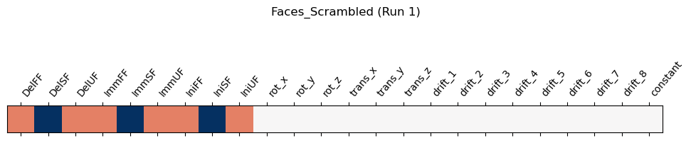

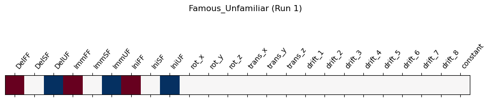

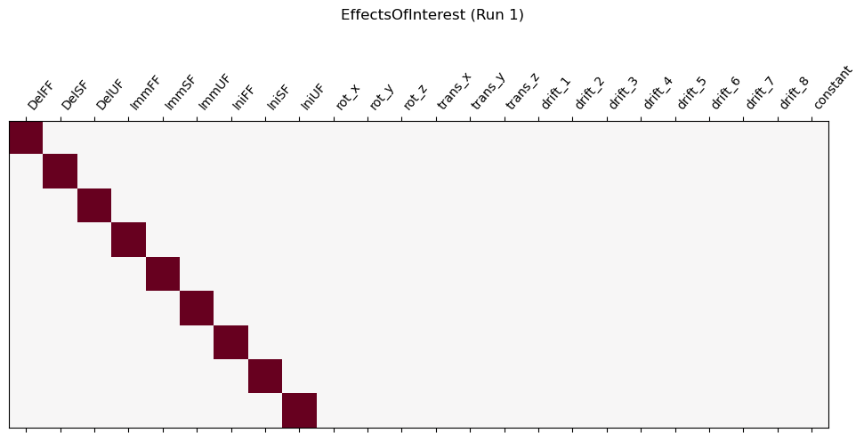

```python
for key, contrast_vectors in contrasts.items():
  plot_contrast_matrix(contrast_vectors[0], design_matrix=design_matrices[0], colorbar=False)
  plt.suptitle(f'{key} (Run 1)')

plt.show()
```

## Computing contrasts and plotting result maps

With Nilearn, you can compute several different statistical maps from a contrast, including effect size maps, t-statistic maps, z-score maps, and more (see the [documentation](https://nilearn.github.io/dev/modules/generated/nilearn.glm.Contrast.html) for details).

**Effect size maps** correspond to the beta (or contrast estimate) maps. These represent the estimated size of the effect for a given condition or contrast. They are useful, for example, when plotting condition-specific betas in ROI analyses (see examples in the ROI analysis notebook), or as inputs for group-level analysis.

For our single-subject analysis, we will now look at a **z-scored statistical map** for the **Faces > Scrambled** contrast. Z-scores tell us how strong the effect is relative to the noise level.

```python
z_map = first_level_model.compute_contrast(
    contrasts["Faces_Scrambled"],
    stat_type="t",
    output_type="z_score",
)

# You can save the z_map to a file
# z_map.to_filename('/path/to/output/z_map.nii.gz')
```

fMRI analyses involve thousands of voxel-wise comparisons, which increases the risk of false positives—famously illustrated by the case of the ["Dead Salmon"](https://teenspecies.github.io/pdfs/NeuralCorrelates.pdf).

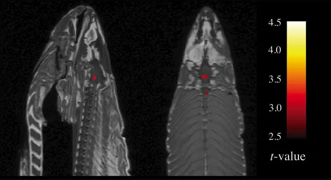

Applying a threshold, particularly one that corrects for multiple comparisons (e.g., using Family-Wise Error (FWE) or False Discovery Rate (FDR) corrections), helps ensure that the displayed activations are statistically reliable. For more information on multiple comparisons correction, see Rik’s Stats tutorial.

### Control the False Positive Rate

A minimum recommendation in the fMRI analysis is to control the **False Positive Rate** (FPR) at a specific threshold, such as p < .001. This is referred to as 'uncorrected' because it does not account for the number of multiple comparisons, but it can still help reduce false positives to a reasonable level when applied conservatively.

```
Uncorrected p<.001 threshold: 3.291
```

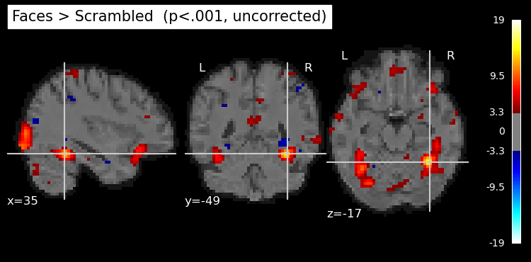

```python
# Obtain the statistical threshold
_, threshold_fpr = threshold_stats_img(
    z_map,
    alpha = .001,
    height_control = 'fpr'
)

print('Uncorrected p<.001 threshold: %.3f' % threshold_fpr)

# plot the thresholded map
plot_stat_map(
    z_map,
    bg_img = preprocessed_anatomical_file,
    threshold = threshold_fpr,
    cut_coords=MNI_coord[0], # let's center the plot on our previously used example voxel
    display_mode = 'ortho',
    black_bg = True,
    cmap = 'cold_hot',
    title = 'Faces > Scrambled  (p<.001, uncorrected)'
)
plt.show()
```

You can save the calculated map to a file:

```python
# z_map.to_filename('FaceRecognition/scratch/sub-15_z_map_faces_scrambled.nii.gz')
```

### False Discovery Rate (FDR) correction

A commonly used alternative to controlling the false positive rate is the **False Discovery Rate** (FDR) method, which addresses the expected proportion of false discoveries among all detected activations. In the case below, it is actually less strict than p<.001 uncorrected. However, in neuroimaging research, the appropriateness of FDR remains a topic of debate. While it is often preferred in exploratory or hypothesis-generating studies due to its balance between discovery and error control, it may be less suitable for confirmatory studies where stricter error control is required. See Rik’s Stats tutorial.

```
FDR, p<.05 threshold: 2.862
```

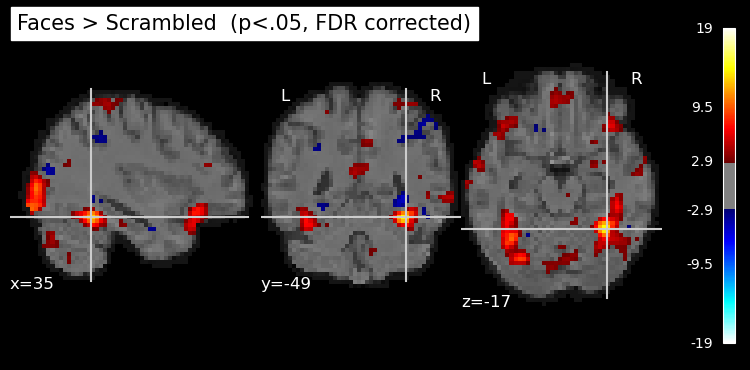

```python
_, threshold_fdr = threshold_stats_img(
    z_map,
    alpha = .05,
    height_control = 'fdr'
)

print('FDR, p<.05 threshold: %.3f' % threshold_fdr)

plot_stat_map(
    z_map,
    bg_img = preprocessed_anatomical_file,
    threshold = threshold_fdr,
    cut_coords=MNI_coord[0], # let's center the plot on our previously used example voxel
    display_mode = 'ortho',
    black_bg = True,
    cmap = 'cold_hot',
    title = 'Faces > Scrambled  (p<.05, FDR corrected)'
)
plt.show()
```